# ANOVA à 2 facteur

Séance 6 de *modèles linéaires

Florent Chuffart & Magali Richard

2019-03-07

# Organisation

## Pré-requis

- R https://cran.r-project.org
- RStudio https://www.rstudio.com

## Evaluation

- individuelle sur un jeu de données aprés 4 séances de cours
- data challenge à la fin des séances

## Supports

- https://github.com/magrichard/cours_modlin_M1

## Découpage prévisionnel

Séance 1 - 3h (10/01) Régression linéaire simple

Séance 2 - 3h (24/01) Régression linéaire multiple

Séance 3 - 3h (31/01) Anova 1 facteur / partie A

Séance 4 - 3h (14/02) Anova 1 facteur / partie B

Séance 5 - 3h (21/02) Data challenge

Séance 6 - 3h (07/03) Anova 2 facteurs

Séance 7 - 3h (11/03) Anova multiple

Séance 8 - 3h (14/03) Anova facteurs emboités

# Plan

### ANOVA à 2 facteurs

1. Rappels ANOVA à un facteur
2. Introduction ANOVA 2 facteurs
3. ANOVA 2 facteurs avec répétion
4. Vérification des conditions
5. Comparaisons multiples
6. ANOVA 2 facteurs sans répétition
7. Introduction au cas non orthogonal
8. ANOVA `à plus de 2 facteurs

# I. Rappels ANOVA à un facteur

$$Y \sim X$$

*X* - L’analyse de la variance (ANOVA) se caractérise par des variables explicatives **qualitatives** (Ex : sexe, couleur des yeux).

*Y* - Dans les deux cas (ANOVA et regression linéaire) la variable expliquée est quantitative (Ex : taille, poids).

L’**ANOVA** à un facteur est un à la fois un **modèle** statistique fondé sur la décomposition de la variance et **test** statistique permettant de comparer les moyennes de plusieurs variables aléatoires indépendantes, gaussiennes et de même variance.

### Un modèle statistique

$$Y_{ij} = \mu + \alpha_i + \epsilon_{ij}$$

où :
$$\sum_{i=1}^I \alpha_i = 0$$

Ainsi :
$$\mu_i = \mu + \alpha_i, i=1,...,I$$

### Test de l’ANOVA

**1) Tableau de l’analyse de la variance**

| Source de variation | sc | ddl | cm | $F_{obs}$ |
| --- | --- | --- | --- | --- |
| Due au facteur | $sc_{F}=\sum(\overline{y}_i-\overline{y}_n)^2$ | $I-1$ | $cm_{F}=\frac{sc_{F}}{I-1}$ | $\frac{cm_{F}}{cm_{res}}$ |
| Résiduelle | $sc_{res}=\sum(y_{ij}-\overline{y}_i)^2$ | $n-I$ | $cm_{res}=\frac{sc_{res}}{n-I}$ |  |
| Totale | $sc_{tot}=\sum(y_{ij}-\overline{y}_n)^2$ | $n-1$ |  |  |

**2) Test**

$\mathcal{H}_0 : \mu_1 = \mu_2 = ... = \mu_I$ contre $\mathcal{H}_1$ : les moyennes $\mu_i$ ne sont pas toutes égales

Satistique du test: $F_{obs} = \frac{cm_{F}}{cm_{res}}$

Pour un seuil donné $\alpha$, les tables de Fisher nous fournissent une valeur critique $c$ telle que $\mathbb{P}_{H_0} [F \leq c] = 1 -\alpha$ Alors nous décidons :

- si $F_{obs} < c$, $\mathcal{H}_0$ est vraie,
- si $F_{obs} \geq c$, $\mathcal{H}_1$ est vraie,

**3) Hypothèses du test**

Les résidus $\widehat{e_{ij}}$ sont associés, sans en être des réalisations, aux variables erreurs $\epsilon_{ij}$ qui sont inobservables et satisfont aux 3 conditions suivantes :

- Indépendance
- Normalité
- Homoscedasticité

# II. Introduction ANOVA à 2 facteurs

## Introduction

La difficulté des approches à plusieurs facteurs est l’identification des sources de variations observées, en prenant en compte la possible **confusion d’effets**

C’est la construction du **plan d’expérience** qui garantira l’interprétabilité des résultats et la capacité du modèle à identifier les sources de variabilités pertinentes

# II. Introduction ANOVA à 2 facteurs

## Plan d’expérience

*La table de contingence* est la table des effectifs croisés entre les modalités des facteurs. Elle définit la répartition des observations en fonction des modalités des facteurs

$k = 1,...,n_{ij}$ est l’indice de répartition, $n_{i\cdot}$ et $n_{\cdot j}$ sont le nombre total d’individus dans la modalité i (j respectivement).

On appellera **plan équilibré** un plan d’expérience tel que $n_{ij}$ est constante.

On appellera **plan orthogonal** un plan d’expérience tel que $n_{ij} = \frac{n_{i\cdot}\times n_{\cdot j}}{n_{\cdot \cdot}}$

Lorsque le plan d’expérience est orthogonal, le modèle permet de séparer les sources de variabilités et donc de quantifier séparemment les contributions de chacun des facteurs.

# II. Introduction ANOVA à 2 facteurs

## Exemple

On souhaite expliquer le nombre de rupture de fil de chaîne (`break`) en fonction du type de laine (`wool`) et de la tension exercée (`tension`).

```r
data(warpbreaks)
attach(warpbreaks)
DT::datatable(warpbreaks)
```

|  | breaks | wool | tension |
| --- | --- | --- | --- |
| 1 | 26 | A | L |
| 2 | 30 | A | L |
| 3 | 54 | A | L |
| 4 | 25 | A | L |
| 5 | 70 | A | L |
| 6 | 52 | A | L |
| 7 | 51 | A | L |
| 8 | 26 | A | L |
| 9 | 67 | A | L |
| 10 | 18 | A | M |

[output cut: 44 more lines]

1. Nous regardons quel type de plan expérimental nous avons.

On note $I$ le facteur $tension$ à 3 modalités L, M et H.

On note $J$ le facteur $wool$ à 2 modalités A et B.

```r
t = table(wool,tension)
t
```

```
##     tension
## wool L M H
##    A 9 9 9
##    B 9 9 9
```

```r
n_ij = 9
n_idot = unique(colSums(t))
n_dotj = unique(rowSums(t))
n_dotdot = dim(warpbreaks)[1]
n_ij == (n_idot*n_dotj)/n_dotdot
```

```
## [1] TRUE
```

- Nous avons un plan équilibré : $n_{ij} = 9$ est constante
- $n_{ij} > 1$
- Nous avons un plan othogonal : $n_{ij} = \frac{n_{i\cdot}\times n_{\cdot j}}{n_{\cdot \cdot}}$
2. Nous nous proposons d’utiliser l’analyse de la variance à deux facteurs. Nous observons trois variables :
- deux d’entre elles sont des variables contrôlées, le type de laine, qualitative à deux modalités, et la tension qui peut être considérée comme qualitative à trois modalités.
- La troisième variable est une réponse quantitative.

On commence par visualiser les données.

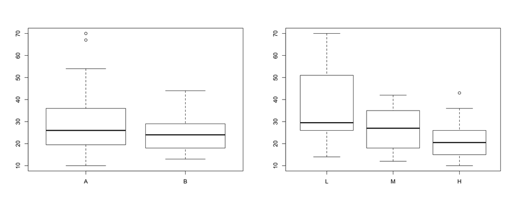

```r
par(mfrow=c(1,2))
plot(wool,breaks)
plot(tension,breaks)
```

La visualisation des effets du couple (wool,tension) sur la moyenne de la variable breaks est la suivante :

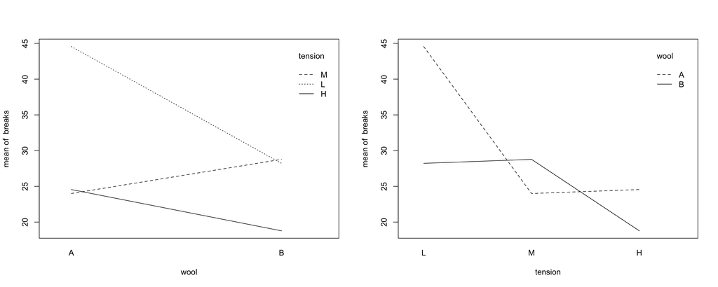

```r
par(mfrow=c(1,2))
interaction.plot(wool,tension,breaks)
interaction.plot(tension,wool,breaks)
```

Les lignes n’étant pas parallèles, nous envisageons un modèle avec interaction des facteurs.

Donc l’analyse de la variance à deux facteurs (type de laine et tension) croisés, avec interaction, peut convenir, entre autres méthodes d’analyse de ces données.

# III. ANOVA 2 facteurs avec répétition

## Modèle statistique avec intéraction

$$Y_{ij} = \mu + \alpha_i + \beta_j +(\alpha\beta)_{ij} + \epsilon_{ijk}$$

$\alpha_i$ et $\beta_j$ sont les effets **principaux**, cela correspond à l’effet marginal des facteurs

$(\alpha\beta)_{ij}$ est un terme d’**intéraction** qui modélise l’effet conjoint des facteurs sur la réponse.

pour $i = 1,...,I$, $j=1,..,J$ et $k = 1,..,K$ avec, pour éviter une surparamétrisation, les contraintes:
$$\sum_{i=1}^I \alpha_i = \sum_{j=1}^J \beta_j = \sum_{i=1}^I (\alpha\beta)_{ij_0}= \sum_{j=1}^J (\alpha\beta)_{i_0j} = 0$$
pour $i_0 = 1,...,I$ et $j_0 = 1,...,J$

# III. ANOVA 2 facteurs avec répétition

## Notion d’intéraction

L’intéraction est une notion statistique permettant d’expliquer les **effets conjoints** de plusieurs facgeurs.

C’est la part de variabilité qui ne peut pas être expliquée séparement par chaque facteur et qui n’est pas dans la résiduelle.

Elle est en général présente mais il n’est pas toujours possible de l’estimer (dépend de la présence de répétition, cf dernière partie de ce cours).

Dans l’interprétation des résultats, on s’interessera d’abords aux termes d’interactions pour savoir s’ils sont significatifs.

**Attention**, si le terme d’interaction est très fort et que le plan expérimental n’est pas orthogonal, alors on ne pourra pas interpréter les effets principaux (non distinguables)

# III. ANOVA 2 facteurs avec répétition

## Hypothèses du modèle

Les variables $\epsilon_{ijk}$ sont ainsi supposées être indépendantes et suivre une loi normale $\mathcal{N}(\mu_{ij},\sigma^2)$.

Leurs réalisations, notées $e_{ijk}$ , sont considérées comme les erreurs de mesure, elles sont inconnues et vérifient :

$$y_{ijk} = \mu + e_{ijk}$$
Pour $i = 1,...,I$, $j=1,..,J$ et $k = 1,..,K$

# III. ANOVA 2 facteurs avec répétition

## Les 3 tests

L’analyse de la variance à deux facteurs avec répétitions permet trois tests de Fisher

### Test 1

Nous testons l’effet du premier facteur $F_1$ : Nous testons l’égalité des $I$ paramètres $\alpha_i$ correspondant aux $I$ modalités du premier facteur

$\mathcal{H}_0$ : les paramètres $\alpha_i$ sont tous nuls *contre* $\mathcal{H}_1$ : les paramètres $\alpha_i$ ne sont pas tous nuls.

### Test 2

Nous testons l’effet du deuxième facteur $F_2$ : Nous testons l’égalité des $J$ paramètres $\beta_j$ correspondant aux $J$ modalités du premier facteur

$\mathcal{H}_0$ : les paramètres $\beta_j$ sont tous nuls *contre* $\mathcal{H}_1$ : les paramètres $\beta_j$ ne sont pas tous nuls.

### Test 3

Nous testons l’effet de l’interaction entre les facteurs $F_1$ et $F_2$.

$\mathcal{H}_0$ : les $IJ$ paramètres $(\alpha\beta)_{ij}$ sont tous nuls *contre* $\mathcal{H}_1$ : les $IJ$ paramètres $(\alpha\beta)_{ij}$ ne sont pas tous nuls.

# III. ANOVA 2 facteurs avec répétition

## Notations

$$\overline{Y}=\frac{1}{n}\sum_{i,j,k}Y_{ijk}$$

$$\overline{Y}_{ij\cdot}=\frac{1}{K}\sum_{k}Y_{ijk}$$

$$\overline{Y}_{i\cdot\cdot}=\frac{1}{JK}\sum_{j,k}Y_{ijk}$$

$$\overline{Y}_{\cdot j\cdot}=\frac{1}{IK}\sum_{i,k}Y_{ijk}$$

$SC_T=\sum_{i,j,k}(Y_{ijk}-\overline{Y})^2$ , $SC_R=\sum_{i,j,k}(Y_{ijk}-\overline{Y}_{ij\cdot})^2$

$SC_{\alpha}=\sum_{i,j,k}(\overline{Y}_{i\cdot\cdot}-\overline{Y})^2$ , $SC_{\beta}=\sum_{i,j,k}(Y_{\cdot j\cdot}-\overline{Y})^2$

$SC_{\alpha\beta}=\sum_{i,j,k}(\overline{Y}_{ij\cdot} - \overline{Y}_{i\cdot\cdot} - \overline{Y}_{\cdot j \cdot}-\overline{Y})^2$

# III. ANOVA 2 facteurs avec répétition

## Equation de l’ANOVA

Léquation de l’anbalyse de la variance devient pour ce modèle :
$$SC_T = SC_R + SC_\alpha + SC_\beta + SC_{\alpha\beta}$$

- la somme $SC_T$ , la **somme totale**, mesure la somme des carrés des écarts à la moyenne globale, toutes causes confondues,
- la somme $SC_R$, **la somme résiduelle**, cumule les carrés des écarts des différentes observations à la moyenne de l’échantillon dont elles font partie. Dans la somme totale elle représente la part de la dispersion due aux **fluctuations individuelles**.
- la somme $SC_\alpha$, la **somme due au premier facteur**, ou somme entre modalités du facteur $F_\alpha$, mesure l’effet du premier facteur.
- la somme $SC_\beta$, ou **somme due au deuxième facteur**, ou somme entre modalités du facteur $F_\beta$, mesure l’effet du deuxième facteur.
- la somme $SC_{\alpha\beta}$ mesure l’effet de **l’interaction entre les deux facteurs**.

# III. ANOVA 2 facteurs avec répétition

## Propriétés

$$\mathcal{L}_{\mathcal{H}_0}\Big(\frac{\frac{SC_\alpha}{I-1}}{\frac{SC_R}{IJ(K-1)}}\Big) = \mathcal{F}_{(I-1),IJ(K-1)}$$
$$\mathcal{L}_{\mathcal{H}_0}\Big(\frac{\frac{SC_\beta}{J-1}}{\frac{SC_R}{IJ(K-1)}}\Big) = \mathcal{F}_{(J-1),IJ(K-1)}$$

$$\mathcal{L}_{\mathcal{H}_0}\Big(\frac{\frac{SC_{\alpha\beta}}{(I-1)(J-1)}}{\frac{SC_R}{IJ(K-1)}}\Big) = \mathcal{F}_{(I-1)(J-1),IJ(K-1)}$$

# III. ANOVA 2 facteurs avec répétition

## Tableau de l’ANOVA

Pour un seuil donné $\alpha$, les tables de Fisher nous fournissent une valeur critique $c$ telle que $\mathbb{P}_{H_0} [F \leq c] = 1 -\alpha$ Alors nous décidons :

- si $F_{obs} < c$, $\mathcal{H}_0$ est vraie,
- si $F_{obs} \geq c$, $\mathcal{H}_1$ est vraie.

### Tableau de l’anova

| Source de variation | sc | ddl | cm | $F_{obs}$ | $F_c$ |
| --- | --- | --- | --- | --- | --- |
| Due à $F_\alpha$ | $sc_\alpha$ | $I-1$ | $cm_{\alpha}=\frac{sc_{\alpha}}{I-1}$ | $\frac{cm_{\alpha}}{cm_{R}}$ | $c_\alpha$ |
| Due à $F_\beta$ | $sc_\beta$ | $J-1$ | $cm_{\beta}=\frac{sc_{\beta}}{J-1}$ | $\frac{cm_{\beta}}{cm_{R}}$ | $c_\beta$ |
| Due à $F_{\alpha\beta}$ | $sc_{\alpha\beta}$ | $(I-1)(J-1)$ | $cm_{\alpha\beta}=\frac{sc_{\alpha\beta}}{(I-1)(J-1)}$ | $\frac{cm_{\alpha\beta}}{cm_{R}}$ | $c_{\alpha\beta}$ |
| Résiduelle | $sc_{R}$ | $IJ(K-1)$ | $cm_{R}=\frac{sc_{R}}{IJ(K-1)}$ |  |  |
| Totale | $sc_{T}$ | $n-1$ |  |  |  |

# III. ANOVA 2 facteurs avec répétition

## Exemple

1. Dans un premier temps, on regarle la pertinence du modèle “global”.

$$\mathcal{L}_{\mathcal{H}_0}\Big(\frac{\frac{SC_{mod}}{(IJ-1)}}{\frac{SC_{res}}{(IJ(k-1))}}\Big)= \mathcal{F}_{(IJ-1),IJ(K-1)}$$

```r
mod =lm(breaks~wool*tension)
summary(mod)
```

```
##
## Call:
## lm(formula = breaks ~ wool * tension)
##
## Residuals:
##      Min       1Q   Median       3Q      Max
## -19.5556  -6.8889  -0.6667   7.1944  25.4444
##
## Coefficients:
##                Estimate Std. Error t value Pr(>|t|)
## (Intercept)      44.556      3.647  12.218 2.43e-16 ***
## woolB           -16.333      5.157  -3.167 0.002677 **
## tensionM        -20.556      5.157  -3.986 0.000228 ***
## tensionH        -20.000      5.157  -3.878 0.000320 ***
## woolB:tensionM   21.111      7.294   2.895 0.005698 **
## woolB:tensionH   10.556      7.294   1.447 0.154327
## ---
## Signif. codes:  0 '***' 0.001 '**' 0.01 '*' 0.05 '.' 0.1 ' ' 1
##
## Residual standard error: 10.94 on 48 degrees of freedom
## Multiple R-squared:  0.3778, Adjusted R-squared:  0.3129
## F-statistic: 5.828 on 5 and 48 DF,  p-value: 0.0002772
```

Le modèle est pertinent et explique 37% de la variabilité (31% si on corrige par le nombre de paramètres).

2. Dans un deuxième temps, on teste les effets des facteurs.

```r
m = aov(breaks~wool*tension)
summary(m)
```

```
##              Df Sum Sq Mean Sq F value   Pr(>F)
## wool          1    451   450.7   3.765 0.058213 .
## tension       2   2034  1017.1   8.498 0.000693 ***
## wool:tension  2   1003   501.4   4.189 0.021044 *
## Residuals    48   5745   119.7
## ---
## Signif. codes:  0 '***' 0.001 '**' 0.01 '*' 0.05 '.' 0.1 ' ' 1
```

```r
coef(m)
```

```
##    (Intercept)          woolB       tensionM       tensionH woolB:tensionM
##       44.55556      -16.33333      -20.55556      -20.00000       21.11111
## woolB:tensionH
##       10.55556
```

Le modèle est significatif: les facteurs ont une influence sur la variable expliquée. On peut remarquer que le coefficient de la variable `wool` n’est pas significatif. Cependant le coefficient des effets croisés `wool:tension` étant significatif, la variable `wool` influence significativmenet la variable `breaks`.

# IV. Vérification des conditions

Pour ce modèle, l’estimation des moyennes théoriques $\mu_{ij}$ se fait par les moyennes observées $\overline{y}_{ij\cdot}$ (« valeurs ajustées »). Les résidus sont alors donnés par l’expression : $\widehat\epsilon_{ijk} = y_{ijk}-\overline{y}_{ij\cdot}$, $i =1,...,I$;$j =1,...,J$;$k =1,...,K$. Leur normalité et l’homogénéité des variances se vérifient par les mêmes méthodes que pour une analyse de la variance à un facteur.

- Indépendance
- Normalité
- Homoscedasticité

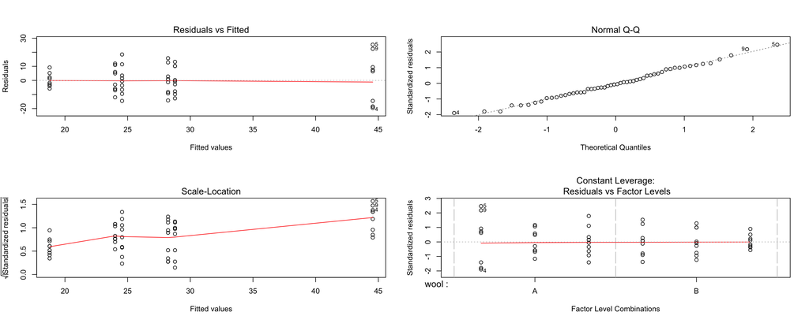

```r
par(mfrow=c(2,2))
m = aov(breaks~wool*tension)
plot(m)
```

Après visualisation graphique, la normalité des résidus semble être respectée, par contre, l’homogénéité de la variance ne semble pas vérifiée.

## Normalité des résidus

```r
shapiro.test(m$residuals)
```

```
##
##  Shapiro-Wilk normality test
##
## data:  m$residuals
## W = 0.98686, p-value = 0.8162
```

## Homogénéité des variances

```r
bartlett.test(breaks,wool)
```

```
##
##  Bartlett test of homogeneity of variances
##
## data:  breaks and wool
## Bartlett's K-squared = 6.9314, df = 1, p-value = 0.00847
```

```r
bartlett.test(breaks,tension)
```

```
##
##  Bartlett test of homogeneity of variances
##
## data:  breaks and tension
## Bartlett's K-squared = 9.6571, df = 2, p-value = 0.007998
```

Cela confirme les observations graphiques.

## Transformation des variables

Nous testons une transformation des variable: la transformation log.

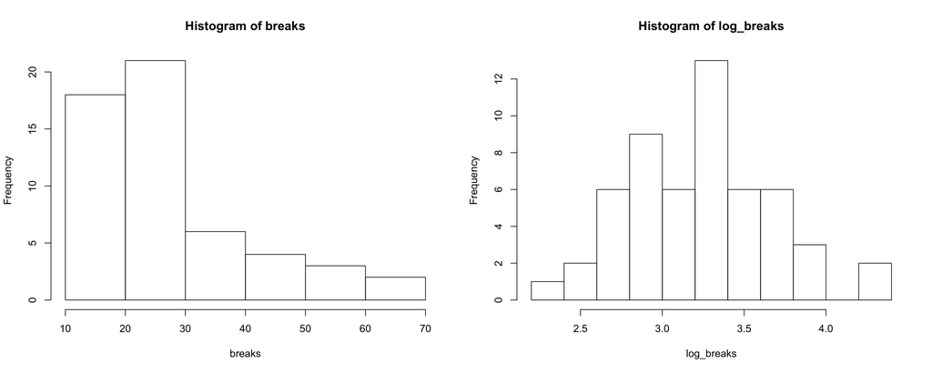

```r
log_breaks = log(breaks)
par(mfrow=c(1,2))
hist(breaks)
hist(log_breaks)
```

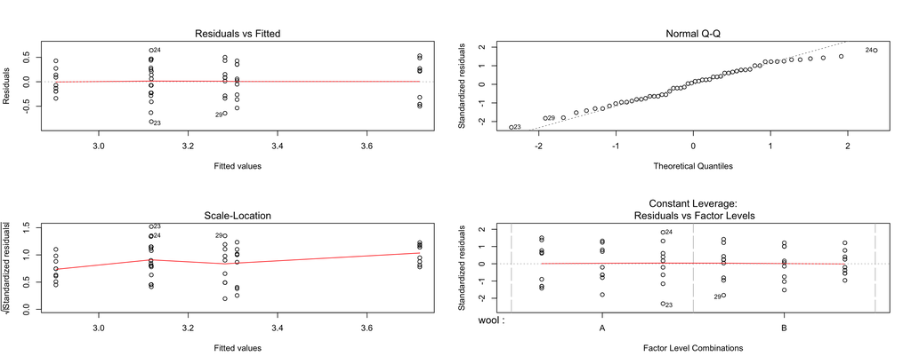

```r
par(mfrow=c(2,2))
m_log = aov(log_breaks~wool*tension)
plot(m_log)
```

```r
shapiro.test(m_log$residuals)
```

```
##
##  Shapiro-Wilk normality test
##
## data:  m_log$residuals
## W = 0.97292, p-value = 0.2583
```

```r
bartlett.test(log_breaks,wool)
```

```
##
##  Bartlett test of homogeneity of variances
##
## data:  log_breaks and wool
## Bartlett's K-squared = 2.3674, df = 1, p-value = 0.1239
```

```r
bartlett.test(log_breaks,tension)
```

```
##
##  Bartlett test of homogeneity of variances
##
## data:  log_breaks and tension
## Bartlett's K-squared = 0.94898, df = 2, p-value = 0.6222
```

# V. Comparaisons multiples

Lorsque l’effet d’un facteur a été mis en évidence, le test de Tukey ou celui de Dunnett s’applique chaque fois que le nombre d’observations le permet, à l’aide de la même statistique. Les effectifs $n_i$ et $n_{i′}$ sont alors ceux des classes comparées.

# V. Comparaisons multiples

## Exemple

```r
res<-lsmeans::lsmeans(m_log,~wool*tension)
pairs(res)
```

```
##  contrast   estimate    SE df t.ratio p.value
##  A,L - B,L  0.435567 0.176 48  2.471  0.1535
##  A,L - A,M  0.601196 0.176 48  3.410  0.0158
##  A,L - B,M  0.408619 0.176 48  2.318  0.2071
##  A,L - A,H  0.600323 0.176 48  3.405  0.0160
##  A,L - B,H  0.813794 0.176 48  4.616  0.0004
##  B,L - A,M  0.165629 0.176 48  0.939  0.9341
##  B,L - B,M -0.026948 0.176 48 -0.153  1.0000
##  B,L - A,H  0.164756 0.176 48  0.935  0.9355
##  B,L - B,H  0.378227 0.176 48  2.145  0.2823
##  A,M - B,M -0.192577 0.176 48 -1.092  0.8821
##  A,M - A,H -0.000873 0.176 48 -0.005  1.0000
##  A,M - B,H  0.212598 0.176 48  1.206  0.8319
##  B,M - A,H  0.191704 0.176 48  1.087  0.8840
##  B,M - B,H  0.405175 0.176 48  2.298  0.2149
##  A,H - B,H  0.213471 0.176 48  1.211  0.8295
##
## P value adjustment: tukey method for comparing a family of 6 estimates
```

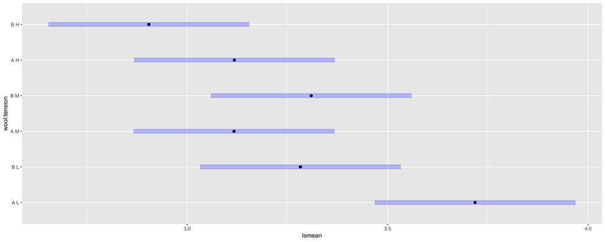

```r
plot(res)
```

Il apparaît que les différences ente les groupes sont peu signicatives, seules 3 p-valeurs corrigées étant inférieures à 5%. On constate que la principale différence est entre les groupes A,L et B,H.

C’est la différence entre ces deux groupes qui expliaue notamment l’influence du facteur `wool`. Au vu des graphiques d’interactions, ce qui nous intéresse est notamment de voir si les groupes A,M et B,M sont similaires.

La p-valeur de 0.8821 nous confime que la différence n’est pas significative

On peut également regarder l’influence de chaque facteur conditionnellement à l’autre facteur. Les résultats obtenus sont donnés ci-après.

```r
res_w = lsmeans::lsmeans(m_log,~wool | tension)
pairs(res_w)
```

```
## tension = L:
##  contrast estimate    SE df t.ratio p.value
##  A - B       0.436 0.176 48  2.471  0.0171
##
## tension = M:
##  contrast estimate    SE df t.ratio p.value
##  A - B      -0.193 0.176 48 -1.092  0.2801
##
## tension = H:
##  contrast estimate    SE df t.ratio p.value
##  A - B       0.213 0.176 48  1.211  0.2319
```

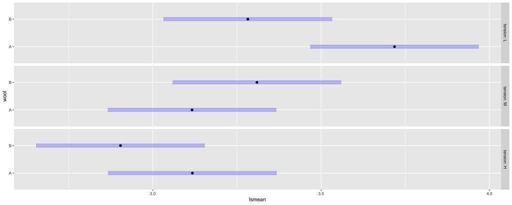

```r
plot(res_w)
```

```r
res_t = lsmeans::lsmeans(m_log,~tension | wool)
pairs(res_t)
```

```
## wool = A:
##  contrast  estimate    SE df t.ratio p.value
##  L - M     0.601196 0.176 48  3.410  0.0037
##  L - H     0.600323 0.176 48  3.405  0.0038
##  M - H    -0.000873 0.176 48 -0.005  1.0000
##
## wool = B:
##  contrast  estimate    SE df t.ratio p.value
##  L - M    -0.026948 0.176 48 -0.153  0.9872
##  L - H     0.378227 0.176 48  2.145  0.0914
##  M - H     0.405175 0.176 48  2.298  0.0657
##
## P value adjustment: tukey method for comparing a family of 3 estimates
```

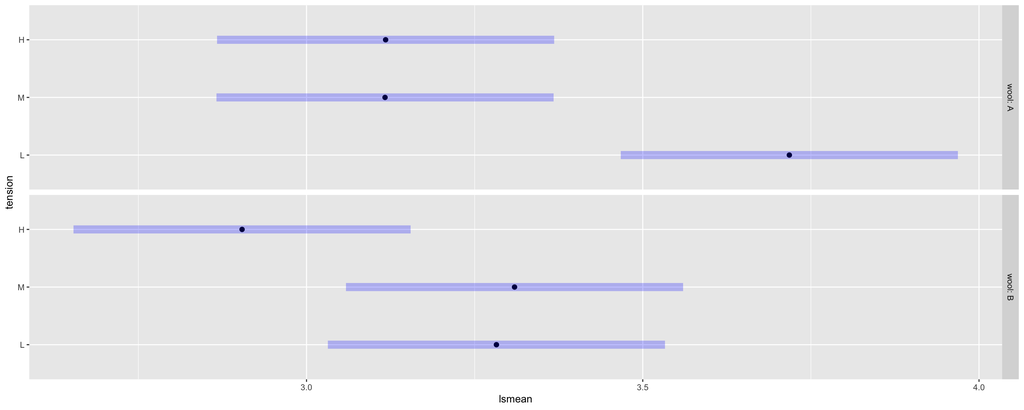

```r
plot(res_t)
```

# VI. ANOVA 2 facteurs sans répétition

Dans le cas où nous étudions l’effet simultané de deux facteurs à, respectivement, $I$ et $J$ modalités et que nous disposons d’une seule observation pour chaque population, c’est à dire $K = 1$, les résultats du paragraphe précédent ne sont plus valables. Nous devons supposer que l’interaction entre les deux facteurs est nulle. Partant du même modèle, nous écrivons plus simplement

$$Y_{ij} = \mu + \alpha_i + \beta_j + \epsilon_{ijk}$$

avec les contraintes:
$$\sum_{i=1}^I \alpha_i = \sum_{j=1}^J \beta_j = 0$$

Remarquons que l’expression définissant, dans le cas avec répétitions, la somme des carrés associée à l’interaction, est associée ici à la somme des carrés de la résiduelle.

| Source de variation | sc | ddl | cm | $F_{obs}$ | $F_c$ |
| --- | --- | --- | --- | --- | --- |
| Due à $F_\alpha$ | $sc_\alpha$ | $I-1$ | $cm_{\alpha}=\frac{sc_{\alpha}}{I-1}$ | $\frac{cm_{\alpha}}{cm_{R}}$ | $c_\alpha$ |
| Due à $F_\beta$ | $sc_\beta$ | $J-1$ | $cm_{\beta}=\frac{sc_{\beta}}{J-1}$ | $\frac{cm_{\beta}}{cm_{R}}$ | $c_\beta$ |
| Résiduelle | $sc_{R}$ | $(I-1)(J-1)$ | $cm_{R}=\frac{sc_{R}}{(I-1)(J-1)}$ |  |  |
| Totale | $sc_{T}$ | $IJ-1$ |  |  |  |

# VII. Cas non-orthogonal

Le cas non-orthogonal est le cas le plus rencontré en pratique

Ces plans d’expériences ne permettent pas de distinguer les effets des différents facteurs de manière unique.

Lorsque l’on effectue un test sur $\alpha_i$, on ne peut pas s’affranchir des autres effets

La décomposition de la somme des carrés du modèle n’est plus unique, on a donc plusieurs façons de la décomposer

Plusieurs test sont possibles (sommes de type I, II, III).

# VIII. ANOVA à plus de 2 facteurs

Dans le cas de plus de deux facteurs, la combinatoire explose pour les interactions d’ordre multiple.

On fait en général l’hypothèse que l’intensité des effets décroit avec l’ordre de l’interaction.

Dans un modèle avec 4 facteurs, on étudiera en général l’effet des facteurs principaux et les interactions d’ordre 2, voire 3.

Pour des modèles avec beaucoup de facteurs, il est crucial de bien comprendre la signification de chaque paramètre.

*Comment identifier les facteurs pertinents?*

- les p-valeurs ajustées peuvent être utiles: elles quantifient la significativité de chaque test
- lorsque beaucoups d’observations sont disponibles, les test deviennent puissants, et identifieront des interactions faibles mais significatives.
- lorsque les p-valeurs sont plus petites que la précision machine ($~10^{-16}$), on peut utiliser les statistiques de Fisher pour comparer l’effet des facteurs et de leurs interactions

# Réferences

Ce cours s’inspire des références suivantes :

- Frédéric Bertrand & Myriam Maumy-Bertrand
- Franck Picard
- Irenne Ganaz